# index

Exercise 1 You will make two maps:

1. Plot your country as the background. Use cx to plot some points (the cities, airports, etc.) below the centroid.
2. Plot your country as the background. Select with cx all the first administrative divisions above the centroid. Then, use clip to show some lines (rivers, railroads, etc) that cross those divisions.

```python
#!pip install geopandas
```

```python
#!pip install fiona
```

```python
import geopandas as gpd
from fiona import listlayers
#countries=gpd.read_file("https://github.com/AdriMA3/introgeodf/raw/refs/heads/main/maps/World_Countries/World_Countries.shp")
#cities=gpd.read_file("https://github.com/AdriMA3/introgeodf/raw/refs/heads/main/maps/World_Cities/World_Cities.shp")
#regiones=gpd.read_file("https://github.com/AdriMA3/introgeodf/raw/refs/heads/main/maps/Regiones/Regional.shp")
#airports=gpd.read_file("https://github.com/AdriMA3/introgeodf/raw/refs/heads/main/data/chile-airports.csv")
#ferrovias=gpd.read_file("https://github.com/AdriMA3/introgeodf/raw/refs/heads/main/maps/Red_Ferroviaria/Red_ferroviaria.shp")
```

```python
chile=countries[countries.COUNTRY=="Chile"]
chile_5361=chile.to_crs(5361)
```

```python
#asignaremos un crs conocido para luego poroyectar
# Asegurar que ambos estén en el mismo CRS antes del clip
ferrovias_aligned = ferrovias.to_crs(chile.crs)

# Realizar el clip
ferroviasChile_clipped = gpd.clip(ferrovias_aligned, chile)

# Luego proyectar al CRS deseado (por ejemplo EPSG:5361)
ferrovias_chile_5361 = ferroviasChile_clipped.to_crs(5361)
```

```python
airports=gpd.GeoDataFrame(data=airports.copy(),
                 geometry=gpd.points_from_xy(airports.longitude_deg,
                                             airports.latitude_deg),
                 crs=chile.crs.to_epsg())
airports_5361=airports.to_crs(5361)
```

```python
regiones.crs
```

```
<Projected CRS: EPSG:3857>
Name: WGS 84 / Pseudo-Mercator
Axis Info [cartesian]:
- X[east]: Easting (metre)
- Y[north]: Northing (metre)
Area of Use:
- name: World between 85.06°S and 85.06°N.
- bounds: (-180.0, -85.06, 180.0, 85.06)
Coordinate Operation:
- name: Popular Visualisation Pseudo-Mercator
- method: Popular Visualisation Pseudo Mercator
Datum: World Geodetic System 1984 ensemble
- Ellipsoid: WGS 84
- Prime Meridian: Greenwich
```

```python
regiones.crs = "EPSG:3857"
```

```python
regiones=regiones.to_crs(5361)
```

```python
chile_centroid=chile.to_crs(5361).centroid
```

```python
cities_chile_5361=cities[cities.COUNTRY=='Chile'].to_crs(5361)
```

```python
#centroide
centroidX,centroidY=chile_5361.centroid.x.values[0],chile_5361.centroid.y.values[0]
#the arriba
regiones_A=regiones.cx[:,centroidY:]
cities_chile_5361_A=cities_chile_5361.cx[:,centroidY:]
airports_5361_A=airports_5361.cx[:,centroidY:]

#the abajo
regiones_B=regiones.cx[:,:centroidY]
cities_chile_5361_B=cities_chile_5361.cx[:,:centroidY]
airports_5361_B=airports_5361.cx[:,:centroidY]
```

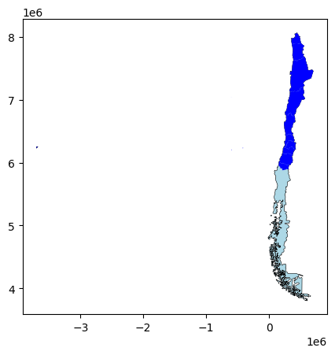

```python
base=chile_5361.plot(facecolor='lightblue',edgecolor='black',linewidth=0.4,figsize=(5,5))
regiones_A.plot(marker='.',color='blue',markersize=13,ax=base)
```

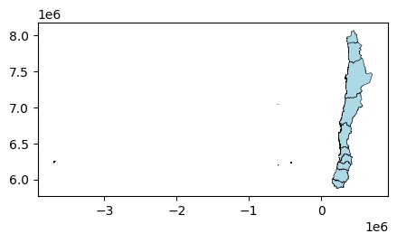

```python
regiones_A.plot(facecolor='lightblue',edgecolor='black',linewidth=0.4,figsize=(5,5))
```

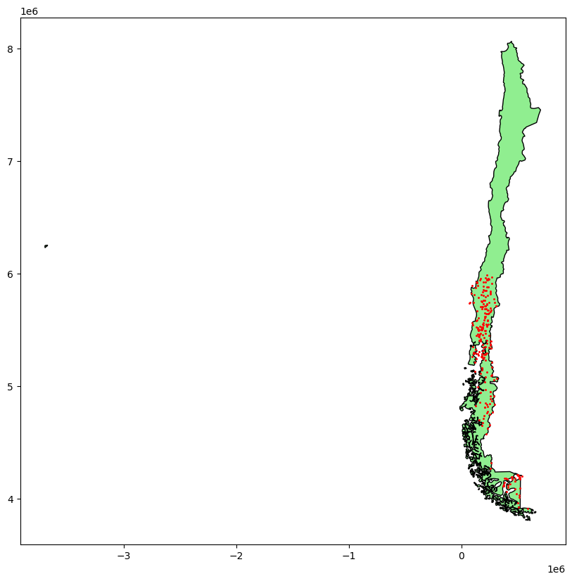

```python
base = chile_5361.plot(facecolor='lightgreen', edgecolor='black', figsize=(10, 10))
airports_5361_B.plot(marker='.', color='red', markersize=5, ax=base)
```

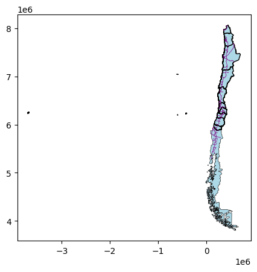

```python
base=chile_5361.plot(facecolor='lightblue',edgecolor='black',linewidth=0.4,figsize=(5,5))
regiones_A.plot(facecolor='lightblue',edgecolor='black',linewidth=1,ax=base)
ferrovias_chile_5361.plot(edgecolor="purple",linewidth=0.5,ax=base)
```

Exercise 2

1.Create some subset of polygons with your country data at the municipal (or similar level). Use Unary UNION with those polygons, and create a geoDF with the result. 2.Dissolve your municipalities by another higher level administrative level. Plot the result. 3.If possible, color some areas of your country by aggregating; if not, plot the "median" values in the indicators map.

```python
import geopandas as gpd
import matplotlib.pyplot as plt
import numpy as np
from shapely.ops import unary_union
```

```python
comunas_gov=gpd.read_file("https://github.com/AdriMA3/introgeodf/raw/refs/heads/main/maps/Comunas/comunas.shp")
```

```python
comunas_gov = comunas_gov.set_crs(epsg=3857, allow_override=True)
comunas_gov_clipped=gpd.clip(comunas_gov,chile)
comunas_gov_5361= comunas_gov_clipped.to_crs(epsg=5361)
```

```python
comunas_gov= comunas_gov.to_crs(5361)
```

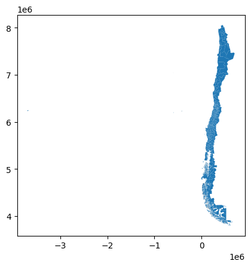

```python
comunas_gov.plot()
```

```python
len(comunas_gov.Region)
```

```
346
```

```python
len(set(comunas_gov.Provincia))
```

```
56
```

```python
!pip show shapely
```

```
Name: shapely
Version: 2.1.1
Summary: Manipulation and analysis of geometric objects
Home-page:
Author: Sean Gillies
Author-email:
License: BSD 3-Clause
Location: /usr/local/lib/python3.11/dist-packages
Requires: numpy
Required-by: bigframes, geopandas, google-cloud-aiplatform, libpysal
```

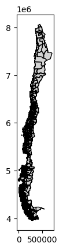

```python
from shapely.geometry import MultiPolygon
union_total = comunas_gov.unary_union

# Extraer el polígono más grande (Chile continental)
if isinstance(union_total,MultiPolygon):
    continente = max(union_total.geoms, key=lambda p: p.area)
else:
    continente = union_total

# Filtrar comunas y regiones que intersectan con el continente
comunas_cont = comunas_gov[comunas_gov.intersects(continente)]

# Visualización
ax = comunas_cont.plot(facecolor='lightgrey', edgecolor='black')
```

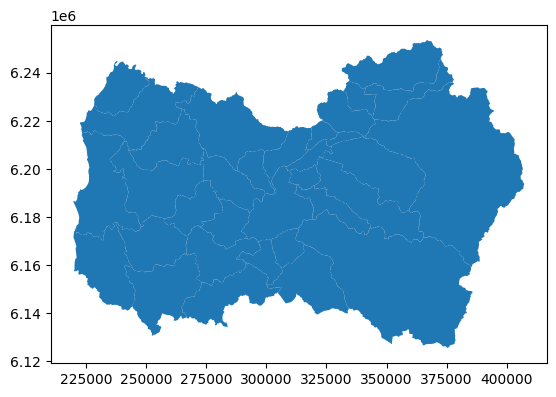

```python
comunas_cont[comunas_cont.Region=="Región del Libertador Bernardo O'Higgins"].plot()
```

```python
comunas_cont[comunas_cont.Region=="Región del Libertador Bernardo O'Higgins"].union_all()
```

[figure not shown]

```python
Region_Libertador=comunas_cont[comunas_cont.Region=="Región del Libertador Bernardo O'Higgins"].union_all()
gpd.GeoDataFrame(index=[0],data={'Region':"Región del Libertador Bernardo O'Higgins"},
                 crs=comunas_cont.crs,
                 geometry=[Region_Libertador])
```

|  | Region | geometry |
| --- | --- | --- |
| 0 | Región del Libertador Bernardo O'Higgins | MULTIPOLYGON (((284438.205 6143707.002, 284422... |

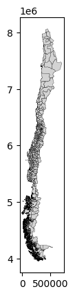

```python
comunas_cont.plot(facecolor="lightgrey",edgecolor="black",linewidth=0.2)
```

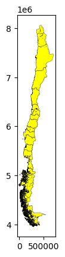

```python
# dissolving
comunas_cont.dissolve(by='Region').plot(facecolor='yellow', edgecolor='black',linewidth=0.2)
```

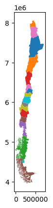

```python
indicatorsbyregion=comunas_cont.dissolve(
     by="Region",
     aggfunc={
         "Comuna": "count",

     },as_index=False,
 )

indicatorsbyregion.plot(column = 'Region')
```

Usaremos la cantidad de población por región para el mapa

```python
poblacion=gpd.read_file("https://github.com/AdriMA3/introgeodf/raw/refs/heads/main/datos%20(1).csv")
```

```python
poblacion.head()
```

|  | field_1 | field_2 | field_3 |
| --- | --- | --- | --- |
| 0 | Unidad territorial | Variable | 2023 |
| 1 | Chile | Población total | 19960889 |
| 2 | Región De Arica Y Parinacota | Población total | 259802.0 |
| 3 | Región De Tarapacá | Población total | 401588.0 |
| 4 | Región De Antofagasta | Población total | 714142.0 |

```python
poblacion.rename(columns={
    'field_1': 'Region',
    'field_2': 'Pobl','field_3': 'Cant'
}, inplace=True)
```

```python
poblacion.head()
```

|  | Region | Pobl | Cant |
| --- | --- | --- | --- |
| 0 | Unidad territorial | Variable | 2023 |
| 1 | Chile | Población total | 19960889 |
| 2 | Región De Arica Y Parinacota | Población total | 259802.0 |
| 3 | Región De Tarapacá | Población total | 401588.0 |
| 4 | Región De Antofagasta | Población total | 714142.0 |

```python
print(poblacion['Region'].unique())
print(comunas_cont['Region'].unique())
```

```
['Unidad territorial' 'Chile' 'Región De Arica Y Parinacota'
 'Región De Tarapacá' 'Región De Antofagasta' 'Región De Atacama'
 'Región De Coquimbo' 'Región De Valparaíso'
 'Región Metropolitana De Santiago'
 "Región Del Libertador Gral. Bernardo O'higgins" 'Región Del Maule'
 'Región del Ñuble' 'Región Del Biobío' 'Región De La Araucanía'
 'Región De Los Ríos' 'Región De Los Lagos'
 'Región De Aysén Del Gral. Carlos Ibáñez Del Campo'
 'Región De Magallanes Y De La Antártica Chilena']
["Región del Libertador Bernardo O'Higgins" 'Región de La Araucanía'
 'Región Metropolitana de Santiago' 'Región de Los Lagos'
 'Región de Los Ríos' 'Región del Maule' 'Región de Coquimbo'
 'Región de Magallanes y Antártica Chilena' 'Zona sin demarcar'
 'Región de Valparaíso' 'Región del Bío-Bío'
 'Región de Aysén del Gral.Ibañez del Campo' 'Región de Tarapacá'
 'Región de Arica y Parinacota' 'Región de Antofagasta' 'Región de Ñuble'
 'Región de Atacama']
```

```python
poblacion['Region'] = poblacion['Region'].str.strip().str.upper()
comunas_cont['Region'] = comunas_cont['Region'].str.strip().str.upper()
```

```python
comunas_con_pob = comunas_cont.merge(poblacion, on='Region', how='left')
```

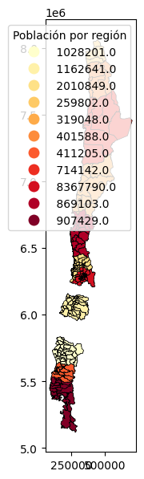

```python
comunas_con_pob.plot(
    column='Cant',
    cmap='YlOrRd',
    legend=True,
    legend_kwds={'title': "Población por región"},
    edgecolor='black',
    linewidth=0.5,
    figsize=(10, 7)
)
```

Exercise 3

1. Select some points from your maps.
2. Create the convex hull for those points.
3. Turn the hull into a GDF.
4. Plot the hull on top of the country.

```python
#airportsCh=gpd.read_file("https://github.com/AdriMA3/introgeodf/raw/refs/heads/main/data/chile-airports.csv")
```

```python
# bye first row
airports.drop(index=0,inplace=True)
airports.reset_index(drop=True, inplace=True)
```

```python
keep=['name','type','latitude_deg', 'longitude_deg','elevation_ft','region_name','municipality']
airports=airports.loc[:,keep]

airports.info()
```

```
<class 'pandas.core.frame.DataFrame'>
RangeIndex: 519 entries, 0 to 518
Data columns (total 7 columns):
 #   Column         Non-Null Count  Dtype
---  ------         --------------  -----
 0   name           519 non-null    object
 1   type           519 non-null    object
 2   latitude_deg   519 non-null    object
 3   longitude_deg  519 non-null    object
 4   elevation_ft   519 non-null    object
 5   region_name    519 non-null    object
 6   municipality   519 non-null    object
dtypes: object(7)
memory usage: 28.5+ KB
```

```python
#remember:
type(airports), type(airports)
```

```
(pandas.core.frame.DataFrame, pandas.core.frame.DataFrame)
```

```python
airports_5361=airports.to_crs(5361)
```

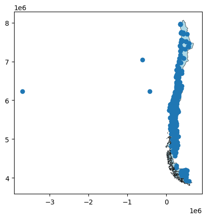

```python
base=chile_5361.plot(facecolor='lightblue',edgecolor='black',linewidth=0.4,figsize=(5,5))
airports_5361.plot(ax=base)
```

```python
# coordinates
centroidX,centroidY=chile_5361.centroid.x.values[0],chile_5361.centroid.y.values[0]

# subsets of medium airports
AirTopLeft=airports_5361[airports_5361['type']=='medium_airport'].cx[:centroidX,centroidY:]
AirTopRight=airports_5361[airports_5361['type']=='medium_airport'].cx[centroidX:,centroidY:]
AirBottomLeft=airports_5361[airports_5361['type']=='medium_airport'].cx[:centroidX,:centroidY]
AirBottomRight=airports_5361[airports_5361['type']=='medium_airport'].cx[centroidX:,:centroidY]
```

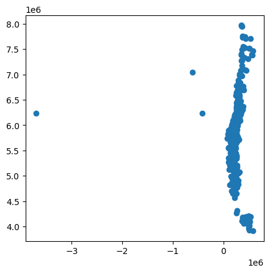

```python
airports_5361.plot()
```

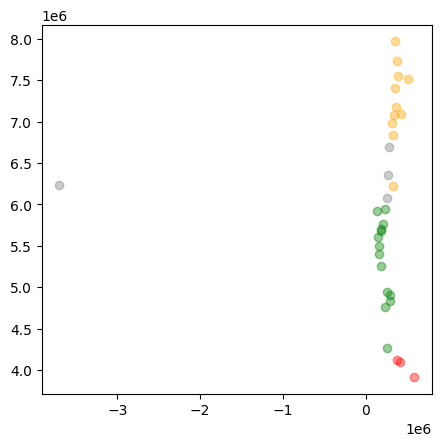

```python
base=AirTopLeft.plot(facecolor='grey', alpha=0.4)
AirTopRight.plot(ax=base,facecolor='orange', alpha=0.4)
AirBottomLeft.plot(ax=base,facecolor='green', alpha=0.4)
AirBottomRight.plot(ax=base,facecolor='red', alpha=0.4)
```

```python
airports_5361['type'].unique()
```

```
array(['large_airport', 'medium_airport', 'small_airport', 'closed',
       'heliport'], dtype=object)
```

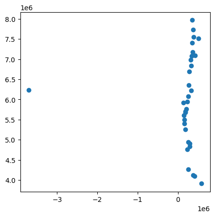

```python
medium_airport = airports_5361[airports_5361['type'] == 'medium_airport']
medium_airport.shape  # para ver cuántos hay
medium_airport.plot()  # para visualizar
```

```python
medium_airport=airports_5361[airports_5361['type']=='medium_airport']
medium_airport.union_all().convex_hull
```

[figure not shown]

```python
medium_airport_hull= gpd.GeoDataFrame(index=[0],
                                    crs=medium_airport.crs,
                                    geometry=[medium_airport.union_all().convex_hull])
medium_airport_hull['name']='medium airport hull' # optional

# then

medium_airport_hull
```

|  | geometry | name |
| --- | --- | --- |
| 0 | POLYGON ((588021.422 3912012.072, -3697936.924... | medium airport hull |

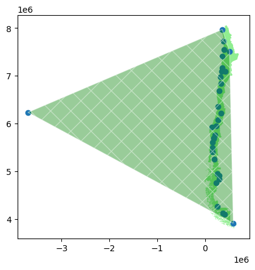

```python
base=chile_5361.plot(facecolor='lightgreen')
medium_airport.plot(ax=base)
medium_airport_hull.plot(ax=base,facecolor='green',
                       edgecolor='white',alpha=0.4,
                       hatch='X')#se dice que esa la zona con más influencia de chile
```

Exercise 4

Apply two spatial overlays to your maps. If possible. If not, try the codes below.

```python
# the north
ComN_chile=comunas_cont.cx[:,centroidY:]
# the south
ComS_chile=comunas_cont.cx[:,:centroidY]
# the west
ComW_chile=comunas_cont.cx[:centroidX,:]
# the east
ComE_chile=comunas_cont.cx[centroidX:,:]
```

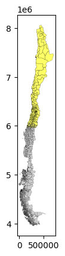

```python
base=ComN_chile.plot(facecolor='yellow', edgecolor='black',linewidth=0.2, alpha=0.6)
ComS_chile.plot(facecolor='grey', edgecolor='black',linewidth=0.2,ax=base, alpha=0.4)
```

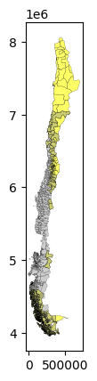

```python
base=ComE_chile.plot(facecolor='yellow', edgecolor='black',linewidth=0.2, alpha=0.6)
ComW_chile.plot(facecolor='grey', edgecolor='black',linewidth=0.2,ax=base, alpha=0.4)
```

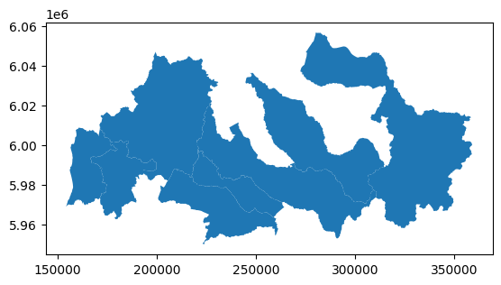

```python
ComNS_chile=ComN_chile.overlay(ComS_chile, how="intersection",keep_geom_type=True)
ComNS_chile.plot()
```

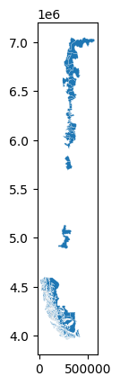

```python
# keeping the overlay
ComWE_chile=ComW_chile.overlay(ComE_chile, how="intersection",keep_geom_type=True)
ComWE_chile.plot(edgecolor='white',linewidth=0.1)
```